# Project: Investigate a Dataset - TMDb movie data

## Introduction

This data set contains information about 10,000 movies collected from The Movie Database (TMDb), including user ratings and revenue.

```
•    Certain columns, like ‘cast’ and ‘genres’, contain multiple values separated by pipe (|) characters.
•    There are some odd characters in the ‘cast’ column. Don’t worry about cleaning them. You can leave them as is.
•    The final two columns ending with “_adj” show the budget and revenue of the movie in terms of 2010 dollars.
```

```python
import pandas as pd
import numpy as np
import matplotlib.pyplot as plt
import seaborn as sns
```

```python
imdb_db = pd.read_csv('tmdb-movies.csv')
imdb_db.head(3)
```

|  | id | imdb_id | popularity | budget | revenue | original_title | cast | homepage | director | tagline | ... | overview | runtime | genres | production_companies | release_date | vote_count | vote_average | release_year | budget_adj | revenue_adj |
| --- | --- | --- | --- | --- | --- | --- | --- | --- | --- | --- | --- | --- | --- | --- | --- | --- | --- | --- | --- | --- | --- |
| 0 | 135397 | tt0369610 | 32.985763 | 150000000 | 1513528810 | Jurassic World | Chris Pratt\|Bryce Dallas Howard\|Irrfan Khan\|Vi... | http://www.jurassicworld.com/ | Colin Trevorrow | The park is open. | ... | Twenty-two years after the events of Jurassic ... | 124 | Action\|Adventure\|Science Fiction\|Thriller | Universal Studios\|Amblin Entertainment\|Legenda... | 6/9/15 | 5562 | 6.5 | 2015 | 1.379999e+08 | 1.392446e+09 |
| 1 | 76341 | tt1392190 | 28.419936 | 150000000 | 378436354 | Mad Max: Fury Road | Tom Hardy\|Charlize Theron\|Hugh Keays-Byrne\|Nic... | http://www.madmaxmovie.com/ | George Miller | What a Lovely Day. | ... | An apocalyptic story set in the furthest reach... | 120 | Action\|Adventure\|Science Fiction\|Thriller | Village Roadshow Pictures\|Kennedy Miller Produ... | 5/13/15 | 6185 | 7.1 | 2015 | 1.379999e+08 | 3.481613e+08 |
| 2 | 262500 | tt2908446 | 13.112507 | 110000000 | 295238201 | Insurgent | Shailene Woodley\|Theo James\|Kate Winslet\|Ansel... | http://www.thedivergentseries.movie/#insurgent | Robert Schwentke | One Choice Can Destroy You | ... | Beatrice Prior must confront her inner demons ... | 119 | Adventure\|Science Fiction\|Thriller | Summit Entertainment\|Mandeville Films\|Red Wago... | 3/18/15 | 2480 | 6.3 | 2015 | 1.012000e+08 | 2.716190e+08 |

3 rows × 21 columns

**We would like to try and find out the answers to the following questions by going through the data:**

1) Total number of movies released from year to year?

2) How does the budget and revenue of movies vary from year to year? What is the gross profit made by the industry based on the data available here? Is there a relation between the budget and revenue?

3) Which are the most popular movies? Which are the highly rated movies? Is there a correlation between the popularity and ratings of the movies?

4) Which genres of movies are released the most?

5) Which director has directed the maximum number of movies?

6) How does the runtime of movies vary?

## Data Wrangling

In this section of the report, we will load in the data, check for cleanliness, and then trim and clean the dataset for analysis.

```python
imdb_db.info()
```

```
<class 'pandas.core.frame.DataFrame'>
RangeIndex: 10866 entries, 0 to 10865
Data columns (total 21 columns):
id                      10866 non-null int64
imdb_id                 10856 non-null object
popularity              10866 non-null float64
budget                  10866 non-null int64
revenue                 10866 non-null int64
original_title          10866 non-null object
cast                    10790 non-null object
homepage                2936 non-null object
director                10822 non-null object
tagline                 8042 non-null object
keywords                9373 non-null object
overview                10862 non-null object
runtime                 10866 non-null int64
genres                  10843 non-null object
production_companies    9836 non-null object
release_date            10866 non-null object
vote_count              10866 non-null int64
vote_average            10866 non-null float64
release_year            10866 non-null int64
budget_adj              10866 non-null float64
revenue_adj             10866 non-null float64
dtypes: float64(4), int64(6), object(11)
memory usage: 1.7+ MB
```

```python
imdb_db.describe()
```

|  | id | popularity | budget | revenue | runtime | vote_count | vote_average | release_year | budget_adj | revenue_adj |
| --- | --- | --- | --- | --- | --- | --- | --- | --- | --- | --- |
| count | 10866.000000 | 10866.000000 | 1.086600e+04 | 1.086600e+04 | 10866.000000 | 10866.000000 | 10866.000000 | 10866.000000 | 1.086600e+04 | 1.086600e+04 |
| mean | 66064.177434 | 0.646441 | 1.462570e+07 | 3.982332e+07 | 102.070863 | 217.389748 | 5.974922 | 2001.322658 | 1.755104e+07 | 5.136436e+07 |
| std | 92130.136561 | 1.000185 | 3.091321e+07 | 1.170035e+08 | 31.381405 | 575.619058 | 0.935142 | 12.812941 | 3.430616e+07 | 1.446325e+08 |
| min | 5.000000 | 0.000065 | 0.000000e+00 | 0.000000e+00 | 0.000000 | 10.000000 | 1.500000 | 1960.000000 | 0.000000e+00 | 0.000000e+00 |
| 25% | 10596.250000 | 0.207583 | 0.000000e+00 | 0.000000e+00 | 90.000000 | 17.000000 | 5.400000 | 1995.000000 | 0.000000e+00 | 0.000000e+00 |
| 50% | 20669.000000 | 0.383856 | 0.000000e+00 | 0.000000e+00 | 99.000000 | 38.000000 | 6.000000 | 2006.000000 | 0.000000e+00 | 0.000000e+00 |
| 75% | 75610.000000 | 0.713817 | 1.500000e+07 | 2.400000e+07 | 111.000000 | 145.750000 | 6.600000 | 2011.000000 | 2.085325e+07 | 3.369710e+07 |
| max | 417859.000000 | 32.985763 | 4.250000e+08 | 2.781506e+09 | 900.000000 | 9767.000000 | 9.200000 | 2015.000000 | 4.250000e+08 | 2.827124e+09 |

Checking to see if all the 10866 id's are unique or not.

```python
imdb_db['id'].unique().size
```

```
10865
```

So there is one account which is repeated in the database. Finding that one account from the database.

```python
#Finding the repeated value
imdb_db['id'].mode()
```

```
0    42194
dtype: int64
```

```python
# Finding the row positions the repeated values correspond to
imdb_db['id'][imdb_db['id']== 42194]
```

```
2089    42194
2090    42194
Name: id, dtype: int64
```

```python
#Printing the information about the repeated values to see if they have same information
print imdb_db.iloc[2089]['original_title']
print imdb_db.iloc[2089]['director']
print ''
print imdb_db.iloc[2090]['original_title']
print imdb_db.iloc[2090]['director']
```

```
TEKKEN
Dwight H. Little

TEKKEN
Dwight H. Little
```

As both the entries are exactly same, therefore, the rows 2089 and 2090 are repeated entries and should be removed from the dataset.

```python
#removing repeated value and printing to see if it is removed from dataset or not
imdb_db.drop(labels=2089,axis=0,inplace=True)
print imdb_db.iloc[2089]['original_title']
print imdb_db.iloc[2089]['director']
print ''
print imdb_db.iloc[2090]['original_title']
print imdb_db.iloc[2090]['director']
```

```
TEKKEN
Dwight H. Little

The Conspirator
Robert Redford
```

Next, checking if any integral or floating point value is NaN.

```python
imdb_db.isnull().any()
```

```
id                      False
imdb_id                  True
popularity              False
budget                  False
revenue                 False
original_title          False
cast                     True
homepage                 True
director                 True
tagline                  True
keywords                 True
overview                 True
runtime                 False
genres                   True
production_companies     True
release_date            False
vote_count              False
vote_average            False
release_year            False
budget_adj              False
revenue_adj             False
dtype: bool
```

None of the integral or floating-point data has NaN values.Next converting the columns contaning strings with delimiters '|' into a list of the names in it.

```python
def convert(element):
    """
    Function to convert a string contaning '|' delimeter
    to a pandas series
    """
    return element.split("|")
```

```python
def convert_columns(database,column):
    """
    Function to use apply method on the passed column of the database
    and separate out the strings in the column to a list of names.

    database: pandas.DataFrame
    column: name of the column in the DataFrame on which the function is to act
    """
    return database[column].dropna().apply(convert)
```

```python
# Updating the various columns contaning strings with delimiters '|' to a series of the names

imdb_db['cast'] = convert_columns(imdb_db,'cast')
imdb_db['genres'] = convert_columns(imdb_db,'genres')
imdb_db['production_companies'] = convert_columns(imdb_db,'production_companies')
```

```python
imdb_db['cast'].head()
```

```
0    [Chris Pratt, Bryce Dallas Howard, Irrfan Khan...
1    [Tom Hardy, Charlize Theron, Hugh Keays-Byrne,...
2    [Shailene Woodley, Theo James, Kate Winslet, A...
3    [Harrison Ford, Mark Hamill, Carrie Fisher, Ad...
4    [Vin Diesel, Paul Walker, Jason Statham, Miche...
Name: cast, dtype: object
```

```python
imdb_db['genres'].head()
```

```
0    [Action, Adventure, Science Fiction, Thriller]
1    [Action, Adventure, Science Fiction, Thriller]
2            [Adventure, Science Fiction, Thriller]
3     [Action, Adventure, Science Fiction, Fantasy]
4                         [Action, Crime, Thriller]
Name: genres, dtype: object
```

```python
imdb_db['production_companies'].head()
```

```
0    [Universal Studios, Amblin Entertainment, Lege...
1    [Village Roadshow Pictures, Kennedy Miller Pro...
2    [Summit Entertainment, Mandeville Films, Red W...
3        [Lucasfilm, Truenorth Productions, Bad Robot]
4    [Universal Pictures, Original Film, Media Righ...
Name: production_companies, dtype: object
```

We can see that columns such as 'homepage', 'tagline','keywords', etc. have a lot less entries in comparision to the 'id' column but we are choosing to ignore it because those columns are not necessary for the analysis here.

Similarly, the entries in the 'release_date' column are in string format rather than as a datetime entry, but we are not converting it to the datetime format as we will be using entries from the 'release_year' column for our analysis.

Next, we see if all the values in the 'revenue' and 'budget' columns are correctly mentioned and are not zero.

```python
# Getting number of movies for which values of revenue is equal to zero
(imdb_db['revenue'] == 0).sum()
```

```
6016
```

```python
# Number of movies for which values of budget is equal to zero
(imdb_db['budget']==0).sum()
```

```
5696
```

Therefore, it is noted that the columns 'revenue' and 'budget' contains zero as values and will be taken it into consideration when analysing them.

## Data Exploration

In this section of the report, we will explore the available data in multiple ways. We will also compute statistics and create visualizations with the goal of addressing the research questions that were posed in the Introduction section.

### Number of movies released each year

```python
#Grouping the movies with respect to their release years
movies_per_year = imdb_db.groupby('release_year')
movies_per_year_count = movies_per_year.agg({'vote_average':'count','budget':'sum','revenue':'sum'})
movies_per_year_count.columns = ['Number of movies', 'Total Budget','Total Revenue']
movies_per_year_count['Number of movies']
```

```
release_year
1960     32
1961     31
1962     32
1963     34
1964     42
1965     35
1966     46
1967     40
1968     39
1969     31
1970     41
1971     55
1972     40
1973     55
```

[output cut: 43 more lines]

Visualizing this through a histogram

```python
%matplotlib inline
```

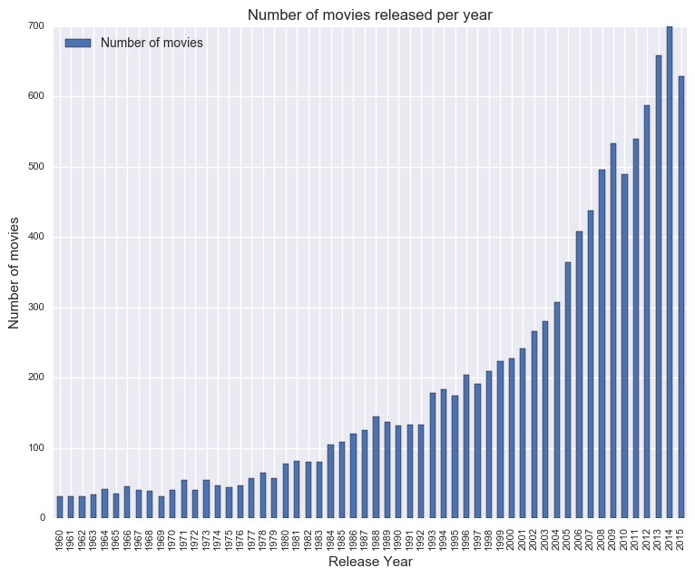

```python
movies_per_year_count['Number of movies'].plot(kind='bar',title="Number of movies released per year",
                                         fontsize=8, legend = True, figsize=(9,7) )
plt.ylabel("Number of movies")
plt.xlabel("Release Year")
```

So, we can concur that there is a general upward trend in the number of movie releases over the years.

### Budget and revenue trend over the years

```python
#printing the total revenue and total budget of the movies over the years
movies_per_year_count[['Total Revenue','Total Budget']]
```

| release_year | Total Revenue | Total Budget |
| --- | --- | --- |
| 1960 | 145005000 | 22056948 |
| 1961 | 337720188 | 46137000 |
| 1962 | 215579846 | 54722126 |
| 1963 | 187404989 | 73331500 |
| 1964 | 340981782 | 39483161 |
| 1965 | 458081854 | 70205115 |
| 1966 | 84736689 | 57554800 |
| 1967 | 737834637 | 100652200 |
| 1968 | 264732980 | 71939000 |
| 1969 | 243957076 | 42129087 |
| 1970 | 560221969 | 126966946 |
| 1971 | 404910610 | 75997000 |
| 1972 | 494730171 | 36279254 |
| 1973 | 1223981102 | 65190783 |
| 1974 | 812539818 | 76970000 |
| 1975 | 957489966 | 56279000 |
| 1976 | 801005600 | 122150000 |
| 1977 | 2180583159 | 161580000 |
| 1978 | 1369779659 | 208997011 |
| 1979 | 1684794913 | 254814000 |
| 1980 | 1768662387 | 362500000 |
| 1981 | 1774606236 | 373757786 |
| 1982 | 2458443852 | 437795002 |
| 1983 | 2307529320 | 519107412 |
| 1984 | 2635524418 | 729211964 |
| 1985 | 2875772392 | 748720637 |
| 1986 | 3002778281 | 704533613 |
| 1987 | 3462104847 | 709455811 |
| 1988 | 3739550845 | 925348000 |
| 1989 | 5164923718 | 1079656360 |
| 1990 | 5315166660 | 1289922066 |
| 1991 | 4706599796 | 1466233000 |
| 1992 | 6078153217 | 1441765370 |
| 1993 | 6955151167 | 1779628653 |
| 1994 | 7095429177 | 2229207032 |
| 1995 | 9156341160 | 2865884377 |
| 1996 | 8311492279 | 3687042051 |
| 1997 | 10655173234 | 4751086675 |
| 1998 | 9493174938 | 4499660000 |
| 1999 | 11355712579 | 5765235106 |
| 2000 | 10978701012 | 5752700000 |
| 2001 | 13410083139 | 5641944000 |
| 2002 | 14643618528 | 5894640255 |
| 2003 | 15138243542 | 6239857694 |
| 2004 | 16793822618 | 7170340222 |
| 2005 | 16516835108 | 7343284349 |
| 2006 | 16275739385 | 7306185300 |
| 2007 | 19411668670 | 7635569004 |
| 2008 | 19431695138 | 7781262597 |
| 2009 | 22180170559 | 8594084056 |
| 2010 | 21959031545 | 9355001006 |
| 2011 | 23695591578 | 9018153652 |
| 2012 | 24668428824 | 8274084052 |
| 2013 | 24703633017 | 9236038361 |
| 2014 | 24331150183 | 7923990138 |
| 2015 | 26762450518 | 7596547557 |

**Note: The 'Total Revenue' and 'Total Budget' columns contain the sum of all values of 'revenue' and 'budget' including the ones listed as 0 as well.**

Visualizing the relation between the Total Budget and the Total Revenue over the years

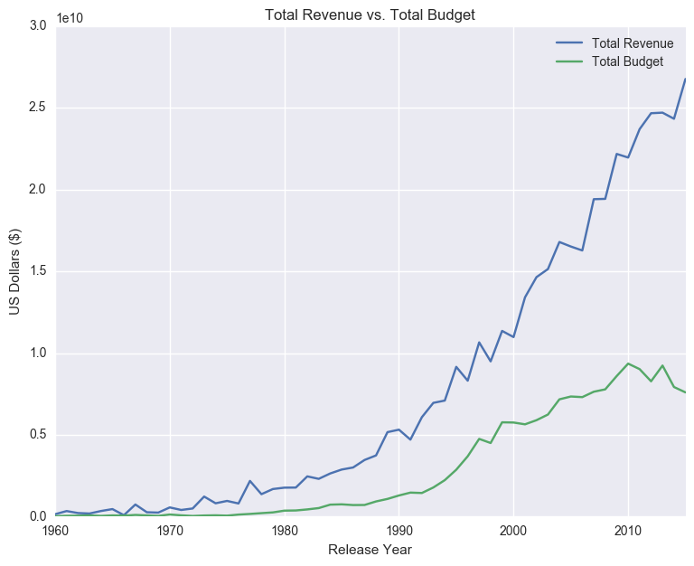

```python
movies_per_year_count['Total Revenue'].plot(kind='line',legend=True,figsize=(9,7))
movies_per_year_count['Total Budget'].plot(kind='line',legend=True,figsize=(9,7))
plt.xlabel('Release Year')
plt.ylabel('US Dollars ($)')
plt.title('Total Revenue vs. Total Budget')
```

The plot above gives us a vague idea of the difference in Total Budget and Total Revenue of the movies released over the past years, but it does not give us enough idea about the early years as the y-axis of the graph had a huge multiple of 1e10 with it. To overcome this and get a better sense of the difference for the early years, plotting the above plot again but with a lograthmic y-axis.

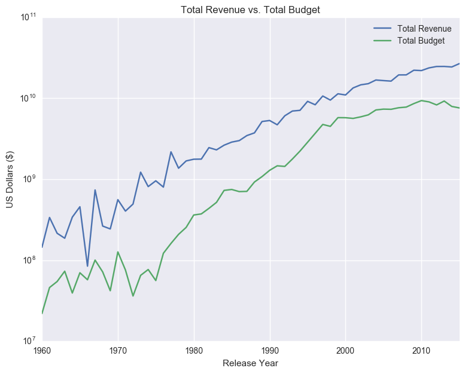

```python
movies_per_year_count['Total Revenue'].plot(kind='line',legend=True,figsize=(9,7))
movies_per_year_count['Total Budget'].plot(kind='line',legend=True,figsize=(9,7))
plt.xlabel('Release Year')
plt.ylabel('US Dollars ($)')
plt.title('Total Revenue vs. Total Budget')
plt.yscale('log')
```

Going by the above two graphs, it can be said that the movie industry has been always in gross profit over the years. Plotting the gross profit over the years.

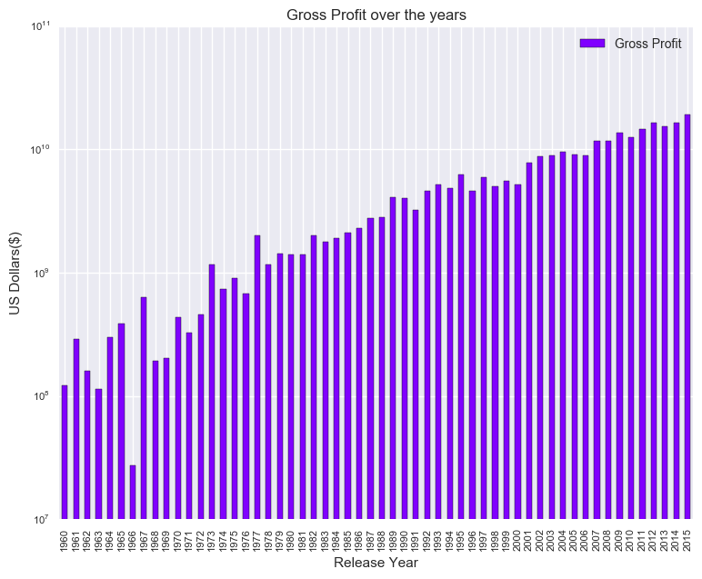

```python
movies_per_year_count['Total Revenue'].sub(movies_per_year_count['Total Budget']).plot(
    kind='bar',logy=True,title='Gross Profit over the years',fontsize=8,colormap='rainbow',figsize=(9,7))
plt.ylabel('US Dollars($)')
plt.legend(['Gross Profit'],loc=0)
plt.xlabel('Release Year')
```

### Relation between Budget and Revenue

Plotting Budget vs Revenue to get a better understanding of thier dependency on each other.

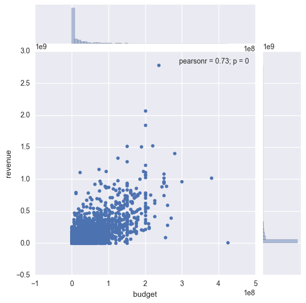

```python
sns.jointplot(data=imdb_db,x='budget',y='revenue')
```

We can also get the correlation for the movie where both the budget and revenue are not zero.

```python
not_zero = imdb_db[(imdb_db['revenue']!=0) & (imdb_db['budget']!=0)]
not_zero.count()
```

```
id                      3854
imdb_id                 3854
popularity              3854
budget                  3854
revenue                 3854
original_title          3854
cast                    3850
homepage                1426
director                3853
tagline                 3574
keywords                3716
overview                3854
runtime                 3854
genres                  3854
production_companies    3808
release_date            3854
vote_count              3854
vote_average            3854
release_year            3854
budget_adj              3854
revenue_adj             3854
dtype: int64
```

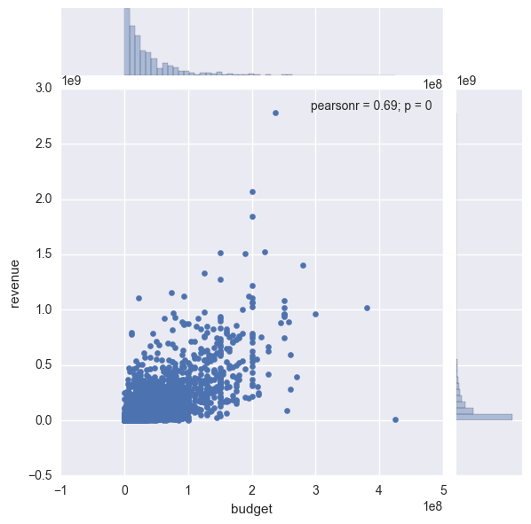

```python
sns.jointplot(data=not_zero,x='budget',y='revenue')
```

This shows that if both the budget and revenue values are given, then they have a 69% correlation between them. But this cannot be implied for the whole dataset as only 3854 entries have both the as non-zero entries.

### Top movies as per popularity

Listing the top 10 movies in the database as per their popularity index.

```python
top_popular_movies = imdb_db.nlargest(10,'popularity') #Getting the top 10 movies as per popularity
top_popular_movies[['original_title','popularity']]
```

|  | original_title | popularity |
| --- | --- | --- |
| 0 | Jurassic World | 32.985763 |
| 1 | Mad Max: Fury Road | 28.419936 |
| 629 | Interstellar | 24.949134 |
| 630 | Guardians of the Galaxy | 14.311205 |
| 2 | Insurgent | 13.112507 |
| 631 | Captain America: The Winter Soldier | 12.971027 |
| 1329 | Star Wars | 12.037933 |
| 632 | John Wick | 11.422751 |
| 3 | Star Wars: The Force Awakens | 11.173104 |
| 633 | The Hunger Games: Mockingjay - Part 1 | 10.739009 |

Having a look at the Budget and Revenue of the top 10 movies to have an idea of how successful they were.

```python
top_popular_movies[['original_title','revenue','budget']]
```

|  | original_title | revenue | budget |
| --- | --- | --- | --- |
| 0 | Jurassic World | 1513528810 | 150000000 |
| 1 | Mad Max: Fury Road | 378436354 | 150000000 |
| 629 | Interstellar | 621752480 | 165000000 |
| 630 | Guardians of the Galaxy | 773312399 | 170000000 |
| 2 | Insurgent | 295238201 | 110000000 |
| 631 | Captain America: The Winter Soldier | 714766572 | 170000000 |
| 1329 | Star Wars | 775398007 | 11000000 |
| 632 | John Wick | 78739897 | 20000000 |
| 3 | Star Wars: The Force Awakens | 2068178225 | 200000000 |
| 633 | The Hunger Games: Mockingjay - Part 1 | 752100229 | 125000000 |

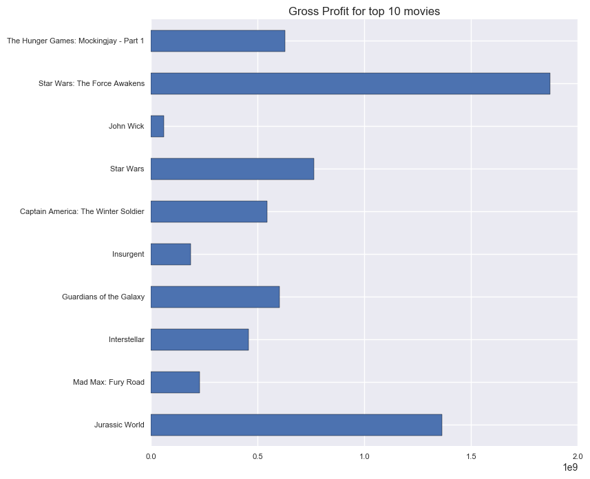

```python
plot1 = top_popular_movies['revenue'].sub(top_popular_movies['budget']).plot(
    kind='barh',title='Gross Profit for top 10 movies',fontsize=8,figsize=(8,8),use_index=False)
plot1.set_yticklabels(top_popular_movies['original_title'])
```

### Top movies as per the vote average (rating)

Listing the top 10 movies in the database as per the average vote value they received.

```python
top_rated_movies = imdb_db.nlargest(10,'vote_average') #Getting the top 10 movies as per popularity
top_rated_movies[['original_title','vote_average']]
```

|  | original_title | vote_average |
| --- | --- | --- |
| 3894 | The Story of Film: An Odyssey | 9.2 |
| 538 | The Mask You Live In | 8.9 |
| 1200 | Black Mirror: White Christmas | 8.8 |
| 2269 | Life Cycles | 8.8 |
| 6911 | Pink Floyd: Pulse | 8.7 |
| 2401 | Opeth: In Live Concert At The Royal Albert Hall | 8.6 |
| 3224 | John Mayer: Where the Light Is Live in Los Ang... | 8.5 |
| 3690 | The Art of Flight | 8.5 |
| 5830 | Doctor Who: The Time of the Doctor | 8.5 |
| 8221 | A Personal Journey with Martin Scorsese Throug... | 8.5 |

Having a look at the Budget and Revenue of the top 10 movies as per ratings to have an idea of how successful they were.

```python
top_rated_movies[['original_title','revenue','budget']]
```

|  | original_title | revenue | budget |
| --- | --- | --- | --- |
| 3894 | The Story of Film: An Odyssey | 0 | 0 |
| 538 | The Mask You Live In | 0 | 0 |
| 1200 | Black Mirror: White Christmas | 0 | 0 |
| 2269 | Life Cycles | 0 | 0 |
| 6911 | Pink Floyd: Pulse | 0 | 0 |
| 2401 | Opeth: In Live Concert At The Royal Albert Hall | 0 | 0 |
| 3224 | John Mayer: Where the Light Is Live in Los Ang... | 0 | 0 |
| 3690 | The Art of Flight | 0 | 0 |
| 5830 | Doctor Who: The Time of the Doctor | 0 | 0 |
| 8221 | A Personal Journey with Martin Scorsese Throug... | 0 | 0 |

As it can be seen, the information regarding the Revenue and Budget is not available for these movies(or rather have a value of 0 instead of the information) and hence the profits for them can not be evaluated.

### Relation between vote average and popularity

As, the information about Budget and Revenue is not present for the top movies based on vote average, visualizing the vote average in comparision to the popularity of the movies.

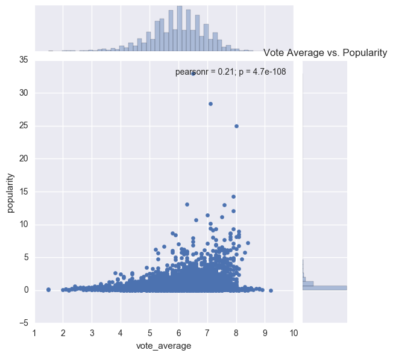

```python
sns.jointplot(data=imdb_db,x='vote_average',y='popularity')
plt.title('Vote Average vs. Popularity')
```

The plot shows that there is a 21% correlation between popularity and vote average of the movies. It also shows that the popularity data has a few outliers and skews the data whereas the vote averages are more uniformly distributed along it's scale.

### Most popular genres

```python
def categorize(data, column):
    """
    Function to categorize the data as per frequency from a dataframe column having lists as elements,
    with each element contaning single or multiple categories.

    data: the dataset on which we are working
    column: the column on which the function is to be applied
    """
    df = pd.DataFrame(columns=[column,'value'])
    for rows in data[column].dropna():
        for row in rows:
            if row not in set(df[column]):
                df = df.append(pd.DataFrame({column:[row],'value':[1]}))
            else:
                location = list(df[column]).index(row)
                df.iloc[location,1] = (df.iloc[location,1]+1)
    df.set_index(column,inplace=True)
    return df
```

```python
genre_proportion = categorize(imdb_db,'genres')
genre_proportion
```

| genres | value |
| --- | --- |
| Action | 2384.0 |
| Adventure | 1471.0 |
| Science Fiction | 1229.0 |
| Thriller | 2907.0 |
| Fantasy | 916.0 |
| Crime | 1354.0 |
| Western | 165.0 |
| Drama | 4760.0 |
| Family | 1231.0 |
| Animation | 699.0 |
| Comedy | 3793.0 |
| Mystery | 810.0 |
| Romance | 1712.0 |
| War | 270.0 |
| History | 334.0 |
| Music | 408.0 |
| Horror | 1637.0 |
| Documentary | 520.0 |
| TV Movie | 167.0 |
| Foreign | 188.0 |

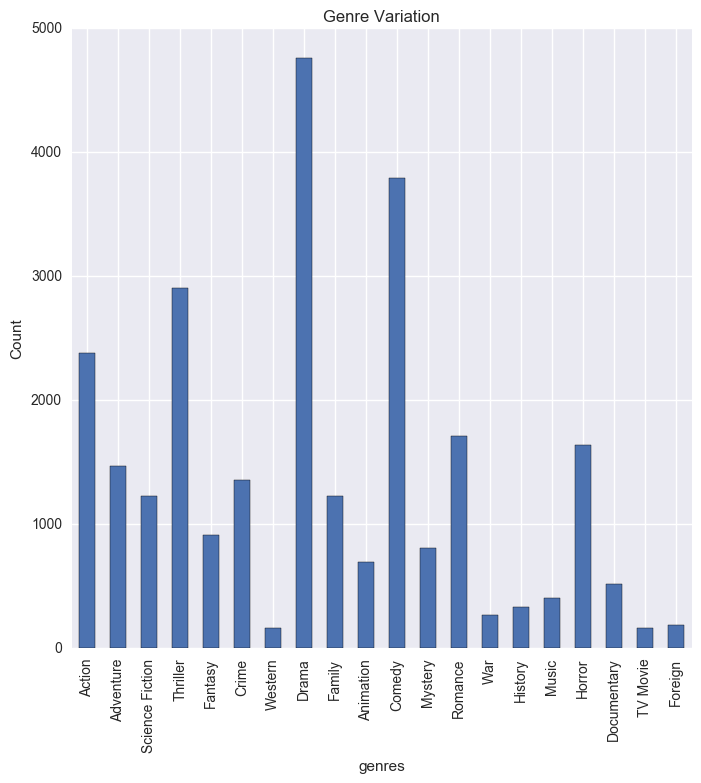

```python
# Plotting the distribution of movies as per genre for the dataset in a pie-chart
genre_proportion.plot(kind='bar', figsize=(8,8),title='Genre Variation',legend=False)
plt.ylabel('Count')
```

From the graph it becomes clear that the most famous Genres are:

```
•    Drama
•    Comedy
•    Thriller
•    Action
•    Romance
```

### Director with the most movies

```python
#Top 10 directors with the most movies
imdb_db['director'].value_counts()[:10]
```

```
Woody Allen          45
Clint Eastwood       34
Martin Scorsese      29
Steven Spielberg     29
Ridley Scott         23
Ron Howard           22
Steven Soderbergh    22
Joel Schumacher      21
Brian De Palma       20
Barry Levinson       19
Name: director, dtype: int64
```

Therefore, 'Woody Allen' is probably the most in-demand director and has been involved in the making of 45 movies. Listing out the movies made by him and their details.

```python
imdb_db[imdb_db['director']=='Woody Allen'][['original_title','popularity','vote_average','budget','revenue']]
```

|  | original_title | popularity | vote_average | budget | revenue |
| --- | --- | --- | --- | --- | --- |
| 155 | Irrational Man | 1.007054 | 6.1 | 11000000 | 27391084 |
| 790 | Magic in the Moonlight | 0.889247 | 6.3 | 0 | 32339326 |
| 1332 | Annie Hall | 1.179653 | 7.6 | 4000000 | 38251425 |
| 1489 | Whatever Works | 0.804857 | 6.7 | 15000000 | 0 |
| 2126 | You Will Meet a Tall Dark Stranger | 0.493121 | 5.8 | 22000000 | 0 |
| 2551 | Sweet and Lowdown | 0.281948 | 6.5 | 0 | 0 |
| 2744 | The Curse of the Jade Scorpion | 0.446532 | 6.1 | 0 | 0 |
| 2964 | Vicky Cristina Barcelona | 0.866771 | 6.7 | 15000000 | 96408652 |
| 3429 | Midnight in Paris | 1.367727 | 7.2 | 30000000 | 151119219 |
| 4046 | Hollywood Ending | 0.444428 | 6.2 | 16000000 | 0 |
| 4250 | Bullets Over Broadway | 0.493082 | 6.7 | 0 | 0 |
| 4493 | To Rome with Love | 0.714232 | 5.5 | 17000000 | 73244881 |
| 5079 | Anything Else | 0.427767 | 6.1 | 0 | 0 |
| 5310 | Deconstructing Harry | 0.567760 | 6.9 | 0 | 0 |
| 5551 | Blue Jasmine | 0.926390 | 6.9 | 18000000 | 97505481 |
| 6116 | The Purple Rose of Cairo | 0.617698 | 7.0 | 15000000 | 10631333 |
| 6248 | Match Point | 1.051177 | 7.1 | 15000000 | 85306374 |
| 6721 | Scoop | 0.489898 | 6.2 | 4000000 | 31584901 |
| 7121 | Melinda and Melinda | 0.425665 | 5.8 | 0 | 20085825 |
| 7278 | Everything You Always Wanted to Know About Sex... | 0.400301 | 6.5 | 2000000 | 18016290 |
| 7355 | Stardust Memories | 0.247924 | 6.3 | 10000000 | 10389003 |
| 7553 | Cassandra's Dream | 0.499794 | 6.1 | 0 | 0 |
| 7835 | Manhattan | 0.961390 | 7.7 | 0 | 39946780 |
| 7978 | Broadway Danny Rose | 0.133990 | 6.6 | 8000000 | 10600497 |
| 8020 | Zelig | 0.388667 | 7.1 | 0 | 11798616 |
| 8119 | Mighty Aphrodite | 0.773291 | 6.5 | 15000000 | 6700000 |
| 8354 | Husbands and Wives | 0.466927 | 5.9 | 0 | 0 |
| 8505 | Everyone Says I Love You | 0.737519 | 6.3 | 20000000 | 0 |
| 8741 | Small Time Crooks | 0.498771 | 6.2 | 0 | 0 |
| 8917 | A Midsummer Night's Sex Comedy | 0.481796 | 5.9 | 0 | 0 |
| 9075 | Celebrity | 0.419482 | 5.9 | 0 | 0 |
| 9238 | Crimes and Misdemeanors | 0.415913 | 6.9 | 19000000 | 18254702 |
| 9372 | Shadows and Fog | 0.267440 | 6.0 | 14000000 | 2735731 |
| 9491 | Another Woman | 0.493264 | 5.8 | 0 | 0 |
| 9640 | Radio Days | 0.420500 | 6.2 | 16000000 | 0 |
| 9667 | September | 0.288278 | 5.5 | 0 | 0 |
| 9817 | Love and Death | 0.491393 | 7.1 | 0 | 0 |
| 9941 | Bananas | 0.448675 | 6.5 | 2000000 | 0 |
| 10030 | Alice | 0.420512 | 5.9 | 0 | 0 |
| 10257 | Manhattan Murder Mystery | 0.755398 | 6.9 | 13500000 | 11285588 |
| 10519 | Hannah and Her Sisters | 0.476819 | 7.3 | 6400000 | 40084041 |
| 10609 | Sleeper | 0.568400 | 6.9 | 2000000 | 18344729 |
| 10729 | Take the Money and Run | 0.589059 | 6.9 | 1500000 | 0 |
| 10804 | Interiors | 0.149259 | 6.3 | 0 | 0 |
| 10864 | What's Up, Tiger Lily? | 0.064317 | 5.4 | 0 | 0 |

### Runtime Analysis

```python
imdb_db['runtime'].value_counts()
```

```
90     547
95     358
100    335
93     328
97     306
96     300
91     297
94     292
98     270
88     270
92     269
89     253
105    250
101    232
99     231
```

[output cut: 47 more lines]

```python
imdb_db['runtime'].describe()
```

```
count    10865.000000
mean       102.071790
std         31.382701
min          0.000000
25%         90.000000
50%         99.000000
75%        111.000000
max        900.000000
Name: runtime, dtype: float64
```

```python
imdb_db['runtime'].mode()
```

```
0    90
dtype: int64
```

Printing out the name of the movies with a runtime of 0 minutes.

```python
imdb_db[imdb_db['runtime']==0]['original_title']
```

```
92           Mythica: The Necromancer
334                           Ronaldo
410                    Anarchy Parlor
445     The Exorcism of Molly Hartley
486                If There Be Thorns
595                         Deep Dark
616                      The Outfield
1241                        Dance-Off
1289                        Treehouse
1293                         Tim Maia
1849                     Spectacular!
2315             Listen to Your Heart
2370                  Freshman Father
3329         Grande, grosso e Verdone
3794             Toi, moi, les autres
```

[output cut: 17 more lines]

Therefore there are 31 movies for which the runtime is mentioned as zero.

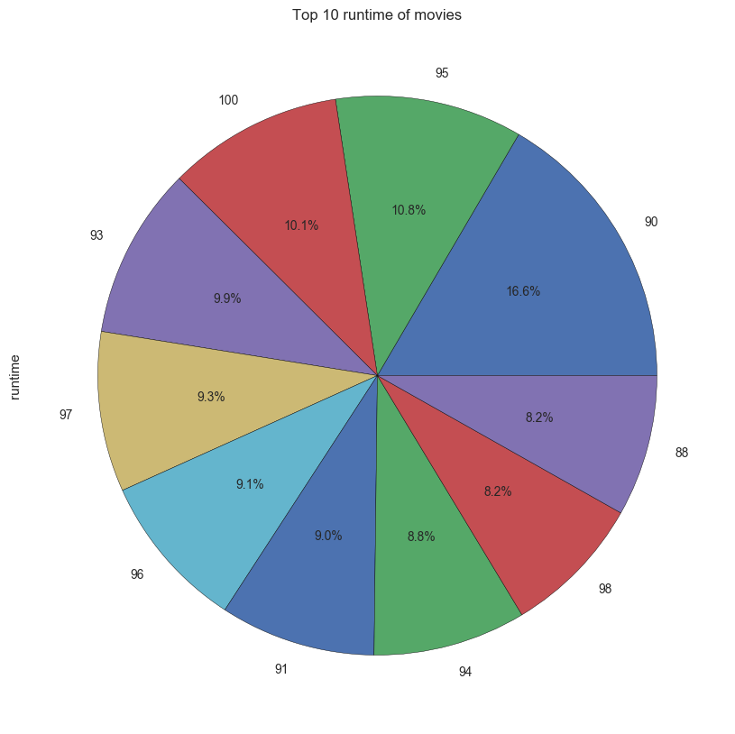

```python
imdb_db.runtime.value_counts()[:10].plot.pie(autopct='%1.1f%%',figsize=(10,10))
plt.title('Top 10 runtime of movies')
```

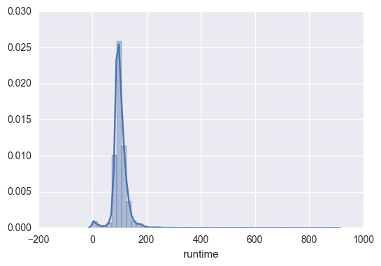

```python
sns.distplot(imdb_db.runtime,hist=True)
```

To get a better understanding of the runtime variation, plotting the values having runtime between 0 and 200 (as it is the prominent region of our data)

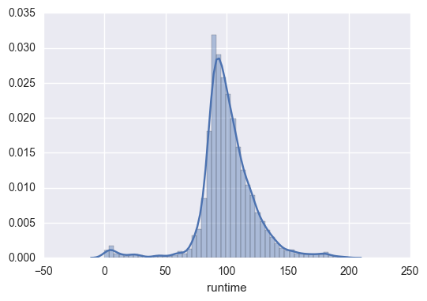

```python
sns.distplot(imdb_db[imdb_db['runtime']<200].runtime,hist=True)
```

Thus, it can be inferred that the most common runtime for movies is about 90-100 minutes.

## Conclusions

**Question:** Total number of movies released from year to year?

**Answer:** There is a general upward trend in the number of movie released over the years, with a maximum 700 being released in 2014

**Question:** Which are the most popular movies? Which are the highly rated movies? Is there a correlation between the popularity and ratings of the movies?

**Answer:** 'Jurassic World' is the most popular movie, while 'The Story of Film: An Odyssey' is the highest rated movie. The top 10 movies as per their popularity as well their ratings are as listed above. The gross profit for the most popular movies is also calculated. A 21% correlation was found between the popularity and ratings of the movies in the dataset.

**Question:** Which genres of movies are released the most?

**Answer:** The most released movies belong to the following genres(in order):

```
•    Drama
•    Comedy
•    Thriller
•    Action
•    Romance
```

**Question:** Which director has directed the maximum number of movies?

**Answer:** Woody Allen has directed the most movies with 'Manhattan' being his highest-rated movie.

**Question:** How does the runtime of movies vary?

**Answer:** The most common runtime for movies is about 90-100 minutes with the longest movie being of 900 minutes. The average running time is about 102 minutes. There are also 31 movies for which the runtime is listed as 0, which is not possible and hence is a limitation to getting the actual average movie running time.

## References

```
•    http://pandas.pydata.org
•    https://stackoverflow.com
•    https://seaborn.pydata.org
•    https://matplotlib.org
•    http://onlinestatbook.com
```